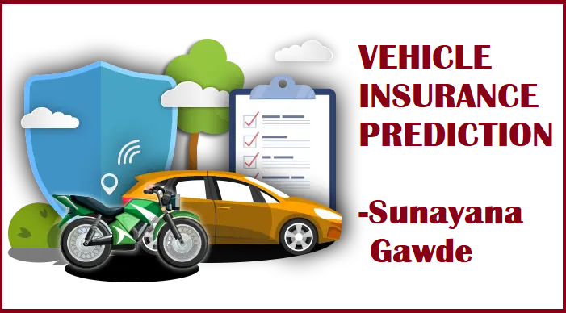

# **Introduction**

## Problem Statement

Client is an Insurance company that has provided Health Insurance to its customers now they need our help in building a model to predict whether the policyholders (customers) from past year will also be interested in Vehicle Insurance provided by the company.

An insurance policy is an arrangement by which a company undertakes to provide a guarantee of compensation for specified loss, damage, illness, or death in return for the payment of a specified premium. A premium is a sum of money that the customer needs to pay regularly to an insurance company for this guarantee.

For example, you may pay a premium of Rs. 5000 each year for a health insurance cover of Rs. 200,000/- so that if, God forbid, you fall ill and need to be hospitalised in that year, the insurance provider company will bear the cost of hospitalisation etc. for upto Rs. 200,000. Now if you are wondering how can company bear such high hospitalisation cost when it charges a premium of only Rs. 5000/-, that is where the concept of probabilities comes in picture. For example, like you, there may be 100 customers who would be paying a premium of Rs. 5000 every year, but only a few of them (say 2-3) would get hospitalised that year and not everyone. This way everyone shares the risk of everyone else.

Just like medical insurance, there is vehicle insurance where every year customer needs to pay a premium of certain amount to insurance provider company so that in case of unfortunate accident by the vehicle, the insurance provider company will provide a compensation (called âsum assuredâ) to the customer.

Building a model to predict whether a customer would be interested in Vehicle Insurance is extremely helpful for the company because it can then accordingly plan its communication strategy to reach out to those customers and optimise its business model and revenue.

Now, in order to predict, whether the customer would be interested in Vehicle insurance, we have information about demographics (gender, age, region code type), Vehicles (Vehicle Age, Damage), Policy (Premium, sourcing channel) etc.

## About Data

### Train Data

| Column Name | Column Description |
| --- | --- |
| id | Unique ID for the customer |
| Gender | Gender of the customer |
| Age | Age of the customer |
| Driving_License | 0 - Customer does not have DL, 1 - Customer already has DL |
| Region_Code | Unique code for the region of the customer |
| Previously_Insured | 1 - Customer already has Vehicle Insurance, 0 - Customer doesn't have Vehicle Insurance |
| Vehicle_Age | Age of the Vehicle |
| Vehicle_Damage | 1 - Customer got his/her vehicle damaged in the past. 0 - Customer didn't get his/her vehicle damaged in the past. |
| Annual_Premium | The amount customer needs to pay as premium in the year |
| Policy_Sales_Channel | Anonymized Code for the channel of outreaching to the customer ie. Different Agents, Over Mail, Over Phone, In Person, etc. |
| Vintage | Number of Days, Customer has been associated with the company |
| Response | 1 - Customer is interested, 0 - Customer is not interested |

### Test Data

| Column Name | Column Description |
| --- | --- |
| id | Unique ID for the customer |
| Gender | Gender of the customer |
| Age | Age of the customer |
| Driving_License | 0 - Customer does not have DL, 1 - Customer already has DL |
| Region_Code | Unique code for the region of the customer |
| Previously_Insured | 1 - Customer already has Vehicle Insurance, 0 - Customer doesn't have Vehicle Insurance |
| Vehicle_Age | Age of the Vehicle |
| Vehicle_Damage | 1 - Customer got his/her vehicle damaged in the past. 0 - Customer didn't get his/her vehicle damaged in the past. |
| Annual_Premium | The amount customer needs to pay as premium in the year |
| Policy_Sales_Channel | Anonymized Code for the channel of outreaching to the customer ie. Different Agents, Over Mail, Over Phone, In Person, etc. |
| Vintage | Number of Days, Customer has been associated with the company |

## To Predict Response based on id

| Column Name | Column Description |
| --- | --- |
| id | Response (1 - Customer is interested, 0 - Customer is not interested) |

# **Importing Libraries**

```python
import numpy as np
import pandas as pd
import seaborn as sns
import plotly.express as px
from plotly.offline import init_notebook_mode, iplot
init_notebook_mode(connected=True)

import warnings
warnings.filterwarnings('ignore')

from sklearn.model_selection import train_test_split
from sklearn.model_selection import cross_val_score
from sklearn.metrics import accuracy_score
from sklearn.model_selection import GridSearchCV, RandomizedSearchCV
from sklearn.metrics import precision_score, recall_score, f1_score

import pickle
```

# **Getting Data**

```python
# Getting both training data and test data from CSV files
trainD = pd.read_csv('/kaggle/input/health-insurance-cross-sell-prediction/train.csv')
testD = pd.read_csv('/kaggle/input/health-insurance-cross-sell-prediction/test.csv')
```

# **Data Exploration & Visualization**

### *This is how the start of the DataFrame looks like*

```python
trainD.head()
```

|  | id | Gender | Age | Driving_License | Region_Code | Previously_Insured | Vehicle_Age | Vehicle_Damage | Annual_Premium | Policy_Sales_Channel | Vintage | Response |
| --- | --- | --- | --- | --- | --- | --- | --- | --- | --- | --- | --- | --- |
| 0 | 1 | Male | 44 | 1 | 28.0 | 0 | > 2 Years | Yes | 40454.0 | 26.0 | 217 | 1 |
| 1 | 2 | Male | 76 | 1 | 3.0 | 0 | 1-2 Year | No | 33536.0 | 26.0 | 183 | 0 |
| 2 | 3 | Male | 47 | 1 | 28.0 | 0 | > 2 Years | Yes | 38294.0 | 26.0 | 27 | 1 |
| 3 | 4 | Male | 21 | 1 | 11.0 | 1 | < 1 Year | No | 28619.0 | 152.0 | 203 | 0 |
| 4 | 5 | Female | 29 | 1 | 41.0 | 1 | < 1 Year | No | 27496.0 | 152.0 | 39 | 0 |

### *These are the columns of the DataFrame*

```python
trainD.columns
```

```
Index(['id', 'Gender', 'Age', 'Driving_License', 'Region_Code',
       'Previously_Insured', 'Vehicle_Age', 'Vehicle_Damage', 'Annual_Premium',
       'Policy_Sales_Channel', 'Vintage', 'Response'],
      dtype='object')
```

### *This is the shape of the DataFrame*

```python
trainD.shape
```

```
(381109, 12)
```

### *This is how any of the row of DataFrame looks like*

```python
trainD.sample()
```

|  | id | Gender | Age | Driving_License | Region_Code | Previously_Insured | Vehicle_Age | Vehicle_Damage | Annual_Premium | Policy_Sales_Channel | Vintage | Response |
| --- | --- | --- | --- | --- | --- | --- | --- | --- | --- | --- | --- | --- |
| 211839 | 211840 | Female | 32 | 1 | 47.0 | 1 | < 1 Year | No | 2630.0 | 152.0 | 220 | 0 |

### *Let's check the info of the DataFrame*

```python
trainD.info()
```

```
<class 'pandas.core.frame.DataFrame'>
RangeIndex: 381109 entries, 0 to 381108
Data columns (total 12 columns):
 #   Column                Non-Null Count   Dtype
---  ------                --------------   -----
 0   id                    381109 non-null  int64
 1   Gender                381109 non-null  object
 2   Age                   381109 non-null  int64
 3   Driving_License       381109 non-null  int64
 4   Region_Code           381109 non-null  float64
 5   Previously_Insured    381109 non-null  int64
 6   Vehicle_Age           381109 non-null  object
 7   Vehicle_Damage        381109 non-null  object
 8   Annual_Premium        381109 non-null  float64
 9   Policy_Sales_Channel  381109 non-null  float64
 10  Vintage               381109 non-null  int64
 11  Response              381109 non-null  int64
dtypes: float64(3), int64(6), object(3)
memory usage: 34.9+ MB
```

### *Looks like there are 12 columns with 3,81,109 records having no null values*

### *Let's check for duplicates*

```python
trainD.duplicated().sum()
```

```
0
```

### *No Duplicated data as well*

### *Let's check with Test Data as well*

```python
testD.info()
```

```
<class 'pandas.core.frame.DataFrame'>
RangeIndex: 127037 entries, 0 to 127036
Data columns (total 11 columns):
 #   Column                Non-Null Count   Dtype
---  ------                --------------   -----
 0   id                    127037 non-null  int64
 1   Gender                127037 non-null  object
 2   Age                   127037 non-null  int64
 3   Driving_License       127037 non-null  int64
 4   Region_Code           127037 non-null  float64
 5   Previously_Insured    127037 non-null  int64
 6   Vehicle_Age           127037 non-null  object
 7   Vehicle_Damage        127037 non-null  object
 8   Annual_Premium        127037 non-null  float64
 9   Policy_Sales_Channel  127037 non-null  float64
 10  Vintage               127037 non-null  int64
dtypes: float64(3), int64(5), object(3)
memory usage: 10.7+ MB
```

```python
testD.duplicated().sum()
```

```
0
```

### *So, there are 11 columns (No output response column) with 1,27,037 records having no null values and also no duplicate values*

### *So, no dealing with missing/null/duplicated values*

### *Let's get the description of all the numeric columns in a DataFrame*

```python
trainD.describe()
```

|  | id | Age | Driving_License | Region_Code | Previously_Insured | Annual_Premium | Policy_Sales_Channel | Vintage | Response |
| --- | --- | --- | --- | --- | --- | --- | --- | --- | --- |
| count | 381109.000000 | 381109.000000 | 381109.000000 | 381109.000000 | 381109.000000 | 381109.000000 | 381109.000000 | 381109.000000 | 381109.000000 |
| mean | 190555.000000 | 38.822584 | 0.997869 | 26.388807 | 0.458210 | 30564.389581 | 112.034295 | 154.347397 | 0.122563 |
| std | 110016.836208 | 15.511611 | 0.046110 | 13.229888 | 0.498251 | 17213.155057 | 54.203995 | 83.671304 | 0.327936 |
| min | 1.000000 | 20.000000 | 0.000000 | 0.000000 | 0.000000 | 2630.000000 | 1.000000 | 10.000000 | 0.000000 |
| 25% | 95278.000000 | 25.000000 | 1.000000 | 15.000000 | 0.000000 | 24405.000000 | 29.000000 | 82.000000 | 0.000000 |
| 50% | 190555.000000 | 36.000000 | 1.000000 | 28.000000 | 0.000000 | 31669.000000 | 133.000000 | 154.000000 | 0.000000 |
| 75% | 285832.000000 | 49.000000 | 1.000000 | 35.000000 | 1.000000 | 39400.000000 | 152.000000 | 227.000000 | 0.000000 |
| max | 381109.000000 | 85.000000 | 1.000000 | 52.000000 | 1.000000 | 540165.000000 | 163.000000 | 299.000000 | 1.000000 |

```python
testD.describe()
```

|  | id | Age | Driving_License | Region_Code | Previously_Insured | Annual_Premium | Policy_Sales_Channel | Vintage |
| --- | --- | --- | --- | --- | --- | --- | --- | --- |
| count | 127037.000000 | 127037.000000 | 127037.000000 | 127037.000000 | 127037.000000 | 127037.000000 | 127037.000000 | 127037.000000 |
| mean | 444628.000000 | 38.765903 | 0.998134 | 26.459866 | 0.460039 | 30524.643576 | 111.800468 | 154.318301 |
| std | 36672.567411 | 15.465814 | 0.043152 | 13.209916 | 0.498403 | 16945.297103 | 54.371765 | 83.661588 |
| min | 381110.000000 | 20.000000 | 0.000000 | 0.000000 | 0.000000 | 2630.000000 | 1.000000 | 10.000000 |
| 25% | 412869.000000 | 25.000000 | 1.000000 | 15.000000 | 0.000000 | 24325.000000 | 26.000000 | 82.000000 |
| 50% | 444628.000000 | 36.000000 | 1.000000 | 28.000000 | 0.000000 | 31642.000000 | 135.000000 | 154.000000 |
| 75% | 476387.000000 | 49.000000 | 1.000000 | 35.000000 | 1.000000 | 39408.000000 | 152.000000 | 227.000000 |
| max | 508146.000000 | 85.000000 | 1.000000 | 52.000000 | 1.000000 | 472042.000000 | 163.000000 | 299.000000 |

### *Let's describe all non-numeric columns as well*

```python
trainD.describe(include = 'object')
```

|  | Gender | Vehicle_Age | Vehicle_Damage |
| --- | --- | --- | --- |
| count | 381109 | 381109 | 381109 |
| unique | 2 | 3 | 2 |
| top | Male | 1-2 Year | Yes |
| freq | 206089 | 200316 | 192413 |

```python
testD.describe(include = 'object')
```

|  | Gender | Vehicle_Age | Vehicle_Damage |
| --- | --- | --- | --- |
| count | 127037 | 127037 | 127037 |
| unique | 2 | 3 | 2 |
| top | Male | 1-2 Year | Yes |
| freq | 68236 | 66699 | 63835 |

### *Let's try to see the impact of different columns on output column by plotting different visualtizations*

```python
trainD.corr()['Response'] # correlation of Response with only numeric columns
```

```
id                     -0.001368
Age                     0.111147
Driving_License         0.010155
Region_Code             0.010570
Previously_Insured     -0.341170
Annual_Premium          0.022575
Policy_Sales_Channel   -0.139042
Vintage                -0.001050
Response                1.000000
Name: Response, dtype: float64
```

```python
trainD.corr()['Response'].plot(kind='bar')
```

[figure not shown]

## Data Visualization

```python
trainD.head()
```

|  | id | Gender | Age | Driving_License | Region_Code | Previously_Insured | Vehicle_Age | Vehicle_Damage | Annual_Premium | Policy_Sales_Channel | Vintage | Response |
| --- | --- | --- | --- | --- | --- | --- | --- | --- | --- | --- | --- | --- |
| 0 | 1 | Male | 44 | 1 | 28.0 | 0 | > 2 Years | Yes | 40454.0 | 26.0 | 217 | 1 |
| 1 | 2 | Male | 76 | 1 | 3.0 | 0 | 1-2 Year | No | 33536.0 | 26.0 | 183 | 0 |
| 2 | 3 | Male | 47 | 1 | 28.0 | 0 | > 2 Years | Yes | 38294.0 | 26.0 | 27 | 1 |
| 3 | 4 | Male | 21 | 1 | 11.0 | 1 | < 1 Year | No | 28619.0 | 152.0 | 203 | 0 |
| 4 | 5 | Female | 29 | 1 | 41.0 | 1 | < 1 Year | No | 27496.0 | 152.0 | 39 | 0 |

```python
#trainD.Gender.unique() # Categorical Data with Male & Female
#trainD.Age.unique() # continuous numeric data
#trainD.Driving_License.unique() # Categorical Data with 0,1
#trainD.Region_Code.unique() # continuous numeric data
#trainD.Previously_Insured.unique() #Categorical Data with 0,1
#trainD.Vehicle_Age.unique() # Categorical Data with 3 values
#trainD.Vehicle_Damage.unique() # Categorical Data with Yes,No
#trainD.Annual_Premium.nunique() # continuous numeric data
#trainD.Policy_Sales_Channel.nunique() # continuous numeric data
#trainD.Vintage.nunique() # continuous numeric data
trainD.Response.unique() # Categorical Data with 0,1
```

```
array([1, 0])
```

### *Univariate Analysis: Plotting all the categorical columns in a countplot*

```python
trainD.Gender.value_counts().plot(kind='bar')
# There are >2 lac males & over 1.75 lac females
```

[figure not shown]

```python
sns.countplot(x='Driving_License',data=trainD)

#trainD['Driving_License'].value_counts().plot(kind='bar')
trainD['Driving_License'].value_counts()

# 3.8 lacs customers with driving licence & only 812 without it
```

```
1    380297
0       812
Name: Driving_License, dtype: int64
```

[figure not shown]

```python
sns.countplot(x='Previously_Insured', data=trainD)
```

[figure not shown]

```python
fig = px.bar(trainD,
             x = trainD.Previously_Insured.value_counts().index,
             y = trainD.Previously_Insured.value_counts().values)

fig.show()

# x = trainD['Previously_Insured'].value_counts().index
# y = trainD['Previously_Insured'].value_counts().values

# df = pd.DataFrame({'Previously_Insured':x,
#                   'Count':y})

# fig = px.bar(df,
#              x='Previously_Insured',
#              y = 'Count')
# fig.show()
```

[interactive chart not shown]

```python
trainD.Vehicle_Age.value_counts().plot(kind='pie',colors=['blue','orange','yellow'],autopct='%.2f')
trainD.Vehicle_Age.value_counts()
```

```
1-2 Year     200316
< 1 Year     164786
> 2 Years     16007
Name: Vehicle_Age, dtype: int64
```

[figure not shown]

```python
sns.countplot(x=trainD.Vehicle_Age,data =trainD)
```

[figure not shown]

```python
sns.countplot(x='Vehicle_Damage', data=trainD)
```

[figure not shown]

```python
# Boxplot
sns.boxplot(trainD['Age']) # There are no outliers
#trainD['Age'].min()
#trainD['Age'].max()
trainD['Age'].mean()
```

```
38.822583565331705
```

[figure not shown]

```python
# Histogram on Numeric data of Age
trainD['Age'].plot(kind='hist',bins=5)
```

[figure not shown]

```python
# Distplot
sns.distplot(trainD['Age'])
```

[figure not shown]

```python
trainD['Age'].skew()
```

```
0.6725389977260843
```

# **Data Preprocessing**

### There are 3 non-numeric columns in a DataFrame:

- Gender
- Vehicle_Age
- Vehicle_Damage

```python
# Dealing with Gender
trainD.Gender.unique()
```

```
array(['Male', 'Female'], dtype=object)
```

```python
trainD.Gender.replace({'Male':1,'Female':2}, inplace=True)
```

```python
trainD.Gender.unique() # Now Gender column in numeric
```

```
array([1, 2])
```

```python
# Dealing with Vehicle_Damage
trainD.Vehicle_Damage.unique()
```

```
array(['Yes', 'No'], dtype=object)
```

```python
trainD.Vehicle_Damage.replace({'Yes':1,'No':0}, inplace=True)
```

```python
trainD.info() # Both columns have become numeric
```

```
<class 'pandas.core.frame.DataFrame'>
RangeIndex: 381109 entries, 0 to 381108
Data columns (total 12 columns):
 #   Column                Non-Null Count   Dtype
---  ------                --------------   -----
 0   id                    381109 non-null  int64
 1   Gender                381109 non-null  int64
 2   Age                   381109 non-null  int64
 3   Driving_License       381109 non-null  int64
 4   Region_Code           381109 non-null  float64
 5   Previously_Insured    381109 non-null  int64
 6   Vehicle_Age           381109 non-null  object
 7   Vehicle_Damage        381109 non-null  int64
 8   Annual_Premium        381109 non-null  float64
 9   Policy_Sales_Channel  381109 non-null  float64
 10  Vintage               381109 non-null  int64
 11  Response              381109 non-null  int64
dtypes: float64(3), int64(8), object(1)
memory usage: 34.9+ MB
```

```python
# Repeat the same for Test Data
#testD.Gender.unique()
testD.Gender.replace({'Male':1,'Female':2}, inplace=True)
#testD.Vehicle_Damage.unique()
testD.Vehicle_Damage.replace({'Yes':1,'No':0}, inplace=True)
```

```python
testD.info() # Both columns have become numeric
```

```
<class 'pandas.core.frame.DataFrame'>
RangeIndex: 127037 entries, 0 to 127036
Data columns (total 11 columns):
 #   Column                Non-Null Count   Dtype
---  ------                --------------   -----
 0   id                    127037 non-null  int64
 1   Gender                127037 non-null  int64
 2   Age                   127037 non-null  int64
 3   Driving_License       127037 non-null  int64
 4   Region_Code           127037 non-null  float64
 5   Previously_Insured    127037 non-null  int64
 6   Vehicle_Age           127037 non-null  object
 7   Vehicle_Damage        127037 non-null  int64
 8   Annual_Premium        127037 non-null  float64
 9   Policy_Sales_Channel  127037 non-null  float64
 10  Vintage               127037 non-null  int64
dtypes: float64(3), int64(7), object(1)
memory usage: 10.7+ MB
```

### Dealing with Vehicle_Age in both Train Data & test Data

```python
trainD.Vehicle_Age.unique() # 3 unique values so replacing with 1,2,3
```

```
array(['> 2 Years', '1-2 Year', '< 1 Year'], dtype=object)
```

```python
trainD.Vehicle_Age.replace({'< 1 Year':1,'1-2 Year':2,'> 2 Years':3}, inplace=True)
```

```python
trainD.Vehicle_Age.unique()
```

```
array([3, 2, 1])
```

```python
# Repeating the same for Test data

#testD.Vehicle_Age.unique()
testD.Vehicle_Age.replace({'< 1 Year':1,'1-2 Year':2,'> 2 Years':3}, inplace=True)
```

```python
testD.Vehicle_Age.unique()
```

```
array([1, 2, 3])
```

### Now all the columns of both DataFrames are numeric

```python
trainD
```

|  | id | Gender | Age | Driving_License | Region_Code | Previously_Insured | Vehicle_Age | Vehicle_Damage | Annual_Premium | Policy_Sales_Channel | Vintage | Response |
| --- | --- | --- | --- | --- | --- | --- | --- | --- | --- | --- | --- | --- |
| 0 | 1 | 1 | 44 | 1 | 28.0 | 0 | 3 | 1 | 40454.0 | 26.0 | 217 | 1 |
| 1 | 2 | 1 | 76 | 1 | 3.0 | 0 | 2 | 0 | 33536.0 | 26.0 | 183 | 0 |
| 2 | 3 | 1 | 47 | 1 | 28.0 | 0 | 3 | 1 | 38294.0 | 26.0 | 27 | 1 |
| 3 | 4 | 1 | 21 | 1 | 11.0 | 1 | 1 | 0 | 28619.0 | 152.0 | 203 | 0 |
| 4 | 5 | 2 | 29 | 1 | 41.0 | 1 | 1 | 0 | 27496.0 | 152.0 | 39 | 0 |
| ... | ... | ... | ... | ... | ... | ... | ... | ... | ... | ... | ... | ... |
| 381104 | 381105 | 1 | 74 | 1 | 26.0 | 1 | 2 | 0 | 30170.0 | 26.0 | 88 | 0 |
| 381105 | 381106 | 1 | 30 | 1 | 37.0 | 1 | 1 | 0 | 40016.0 | 152.0 | 131 | 0 |
| 381106 | 381107 | 1 | 21 | 1 | 30.0 | 1 | 1 | 0 | 35118.0 | 160.0 | 161 | 0 |
| 381107 | 381108 | 2 | 68 | 1 | 14.0 | 0 | 3 | 1 | 44617.0 | 124.0 | 74 | 0 |
| 381108 | 381109 | 1 | 46 | 1 | 29.0 | 0 | 2 | 0 | 41777.0 | 26.0 | 237 | 0 |

381109 rows Ã 12 columns

```python
trainD.drop("id", inplace=True, axis=1)
```

```python
testD.drop("id", inplace=True, axis=1)
```

```python
#numeric_cols = ["Age","Region_Code","Annual_Premium", "Policy_Sales_Channel", "Vintage"]
```

```python
# from sklearn.preprocessing import MinMaxScaler
# scaler=MinMaxScaler()
# scaler.fit(trainD[numeric_cols])
# trainD[numeric_cols]=scaler.transform(trainD[numeric_cols])
#testD[numeric_cols]=scaler.transform(testD[numeric_cols])
```

```python
trainD
```

|  | Gender | Age | Driving_License | Region_Code | Previously_Insured | Vehicle_Age | Vehicle_Damage | Annual_Premium | Policy_Sales_Channel | Vintage | Response |
| --- | --- | --- | --- | --- | --- | --- | --- | --- | --- | --- | --- |
| 0 | 1 | 44 | 1 | 28.0 | 0 | 3 | 1 | 40454.0 | 26.0 | 217 | 1 |
| 1 | 1 | 76 | 1 | 3.0 | 0 | 2 | 0 | 33536.0 | 26.0 | 183 | 0 |
| 2 | 1 | 47 | 1 | 28.0 | 0 | 3 | 1 | 38294.0 | 26.0 | 27 | 1 |
| 3 | 1 | 21 | 1 | 11.0 | 1 | 1 | 0 | 28619.0 | 152.0 | 203 | 0 |
| 4 | 2 | 29 | 1 | 41.0 | 1 | 1 | 0 | 27496.0 | 152.0 | 39 | 0 |
| ... | ... | ... | ... | ... | ... | ... | ... | ... | ... | ... | ... |
| 381104 | 1 | 74 | 1 | 26.0 | 1 | 2 | 0 | 30170.0 | 26.0 | 88 | 0 |
| 381105 | 1 | 30 | 1 | 37.0 | 1 | 1 | 0 | 40016.0 | 152.0 | 131 | 0 |
| 381106 | 1 | 21 | 1 | 30.0 | 1 | 1 | 0 | 35118.0 | 160.0 | 161 | 0 |
| 381107 | 2 | 68 | 1 | 14.0 | 0 | 3 | 1 | 44617.0 | 124.0 | 74 | 0 |
| 381108 | 1 | 46 | 1 | 29.0 | 0 | 2 | 0 | 41777.0 | 26.0 | 237 | 0 |

381109 rows Ã 11 columns

```python
trainD.describe()
```

|  | Gender | Age | Driving_License | Region_Code | Previously_Insured | Vehicle_Age | Vehicle_Damage | Annual_Premium | Policy_Sales_Channel | Vintage | Response |
| --- | --- | --- | --- | --- | --- | --- | --- | --- | --- | --- | --- |
| count | 381109.000000 | 381109.000000 | 381109.000000 | 381109.000000 | 381109.000000 | 381109.000000 | 381109.000000 | 381109.000000 | 381109.000000 | 381109.000000 | 381109.000000 |
| mean | 1.459239 | 38.822584 | 0.997869 | 26.388807 | 0.458210 | 1.609616 | 0.504877 | 30564.389581 | 112.034295 | 154.347397 | 0.122563 |
| std | 0.498336 | 15.511611 | 0.046110 | 13.229888 | 0.498251 | 0.567439 | 0.499977 | 17213.155057 | 54.203995 | 83.671304 | 0.327936 |
| min | 1.000000 | 20.000000 | 0.000000 | 0.000000 | 0.000000 | 1.000000 | 0.000000 | 2630.000000 | 1.000000 | 10.000000 | 0.000000 |
| 25% | 1.000000 | 25.000000 | 1.000000 | 15.000000 | 0.000000 | 1.000000 | 0.000000 | 24405.000000 | 29.000000 | 82.000000 | 0.000000 |
| 50% | 1.000000 | 36.000000 | 1.000000 | 28.000000 | 0.000000 | 2.000000 | 1.000000 | 31669.000000 | 133.000000 | 154.000000 | 0.000000 |
| 75% | 2.000000 | 49.000000 | 1.000000 | 35.000000 | 1.000000 | 2.000000 | 1.000000 | 39400.000000 | 152.000000 | 227.000000 | 0.000000 |
| max | 2.000000 | 85.000000 | 1.000000 | 52.000000 | 1.000000 | 3.000000 | 1.000000 | 540165.000000 | 163.000000 | 299.000000 | 1.000000 |

### **Let's work on Train Data**: We will find the correlation of each column with output column in Train Data.

```python
trainD.corr()['Response'] # Finding correlation with Response column
```

```
Gender                 -0.052440
Age                     0.111147
Driving_License         0.010155
Region_Code             0.010570
Previously_Insured     -0.341170
Vehicle_Age             0.221874
Vehicle_Damage          0.354400
Annual_Premium          0.022575
Policy_Sales_Channel   -0.139042
Vintage                -0.001050
Response                1.000000
Name: Response, dtype: float64
```

```python
trainD.corr()['Response'].plot(kind='bar')
```

[figure not shown]

- We see that Response is positively dependant on 'vehicle damaged', 'vehicle age' and then 'Age' of the owner
- It is inversely dependant on 'Previously Insured' and 'Policy sales channel'

```python
#To know exact values, I'm plotting plotly bar graph
px.bar(trainD.corr()['Response'])
```

[interactive chart not shown]

### Feature Selection: We will consider those values which are more than 20% i.e.

- Vehicle_Damage (35.43%)
- Previously_Insured (34.11%)
- Vehicle_Age (22.18)

# **Machine Learning**

### Machine Learning can be defined as teaching our machines certain things, certain processes so that machine can behave correctly as per the knowledge it gains from learning.

- We have this tabular data which gives information about the customers of insurance company and their insurance buying choice.
- We will try different algorithms to train the model using this train data and test the models using test data.
- We have to predict whether the customer will buy the insurance or not on test data given.

### *We have to select the columns for training the model*

```python
trainD.head()
```

|  | Gender | Age | Driving_License | Region_Code | Previously_Insured | Vehicle_Age | Vehicle_Damage | Annual_Premium | Policy_Sales_Channel | Vintage | Response |
| --- | --- | --- | --- | --- | --- | --- | --- | --- | --- | --- | --- |
| 0 | 1 | 44 | 1 | 28.0 | 0 | 3 | 1 | 40454.0 | 26.0 | 217 | 1 |
| 1 | 1 | 76 | 1 | 3.0 | 0 | 2 | 0 | 33536.0 | 26.0 | 183 | 0 |
| 2 | 1 | 47 | 1 | 28.0 | 0 | 3 | 1 | 38294.0 | 26.0 | 27 | 1 |
| 3 | 1 | 21 | 1 | 11.0 | 1 | 1 | 0 | 28619.0 | 152.0 | 203 | 0 |
| 4 | 2 | 29 | 1 | 41.0 | 1 | 1 | 0 | 27496.0 | 152.0 | 39 | 0 |

### *Creating new DataFrame with required input(decided in previous step) and output columns only*

```python
trainDF = trainD.loc[:,['Vehicle_Damage','Previously_Insured','Vehicle_Age','Response']]

# Vehicle_Damage (35.43%)
# Previously_Insured (34.11%)
# Vehicle_Age (22.18)
trainDF
```

|  | Vehicle_Damage | Previously_Insured | Vehicle_Age | Response |
| --- | --- | --- | --- | --- |
| 0 | 1 | 0 | 3 | 1 |
| 1 | 0 | 0 | 2 | 0 |
| 2 | 1 | 0 | 3 | 1 |
| 3 | 0 | 1 | 1 | 0 |
| 4 | 0 | 1 | 1 | 0 |
| ... | ... | ... | ... | ... |
| 381104 | 0 | 1 | 2 | 0 |
| 381105 | 0 | 1 | 1 | 0 |
| 381106 | 0 | 1 | 1 | 0 |
| 381107 | 1 | 0 | 3 | 0 |
| 381108 | 0 | 0 | 2 | 0 |

381109 rows Ã 4 columns

### **Now we will use this trainDF as a whole dataset for training the model as well as testing and finding accuracy. (since given test file does not have output column, we can't use it to find accuracy, we will use that file as an input to the final model and find output)**

### *Extract Input & Output Columns*

```python
X = trainDF.iloc[:,0:3]
y = trainDF.iloc[:,-1]
X
```

|  | Vehicle_Damage | Previously_Insured | Vehicle_Age |
| --- | --- | --- | --- |
| 0 | 1 | 0 | 3 |
| 1 | 0 | 0 | 2 |
| 2 | 1 | 0 | 3 |
| 3 | 0 | 1 | 1 |
| 4 | 0 | 1 | 1 |
| ... | ... | ... | ... |
| 381104 | 0 | 1 | 2 |
| 381105 | 0 | 1 | 1 |
| 381106 | 0 | 1 | 1 |
| 381107 | 1 | 0 | 3 |
| 381108 | 0 | 0 | 2 |

381109 rows Ã 3 columns

### **Is scaling required?**

- Look at the mean of all 3 input columns
- Values look like in a similar range
- So, scaling is not required.

```python
trainDF.describe()
```

|  | Vehicle_Damage | Previously_Insured | Vehicle_Age | Response |
| --- | --- | --- | --- | --- |
| count | 381109.000000 | 381109.000000 | 381109.000000 | 381109.000000 |
| mean | 0.504877 | 0.458210 | 1.609616 | 0.122563 |
| std | 0.499977 | 0.498251 | 0.567439 | 0.327936 |
| min | 0.000000 | 0.000000 | 1.000000 | 0.000000 |
| 25% | 0.000000 | 0.000000 | 1.000000 | 0.000000 |
| 50% | 1.000000 | 0.000000 | 2.000000 | 0.000000 |
| 75% | 1.000000 | 1.000000 | 2.000000 | 0.000000 |
| max | 1.000000 | 1.000000 | 3.000000 | 1.000000 |

### *Splitting the data into Training & Testing Data*

```python
X_train,X_test,y_train,y_test = train_test_split(X,y,test_size=0.2)
```

```python
# from sklearn.model_selection import StratifiedShuffleSplit
# split = StratifiedShuffleSplit(n_splits=1, test_size=0.2, random_state=42)
# for train_indices, test_indices in split.split(trainD, trainD['Response']):
#     strat_train_set = trainD.loc[train_indices]
#     strat_test_set = trainD.loc[test_indices]
```

```python
#strat_train_set
```

```python
#strat_test_set["Response"].value_counts()
```

```python
# X_train = strat_train_set.iloc[:,0:-1]
# y_train = strat_train_set.iloc[:,-1]

# X_test = strat_test_set.iloc[:,0:-1]
# y_test = strat_test_set.iloc[:,-1]
```

```python
print(X_train.shape)
print(X_test.shape)
print(y_train.shape)
print(y_test.shape)
```

```
(304887, 3)
(76222, 3)
(304887,)
(76222,)
```

### *Training the model using different algorithms*

- We need to predict whether customer will buy the insurance or not. So it's a classification problem.
- We will try few classification ML algorithms to train the model and then find the accuracy based on the splitted test file.

### **Logistic Regression**

- Logistic Regression is actually a classification problem used to predict a binary outcome: either something happens, or does not. This can be exhibited as Yes/No, Pass/Fail, Alive/Dead, etc.
- Independent variables are analyzed to determine the binary outcome with the results falling into one of two categories.

```python
from sklearn.linear_model import LogisticRegression
lr_clf = LogisticRegression()

lr_clf.fit(X_train,y_train)
y_pred = lr_clf.predict(X_test)
print("Accuracy Score: ",accuracy_score(y_test,y_pred))
scores = cross_val_score(lr_clf, X_train, y_train, cv=10) #CV 10 times
print("Accuracy Score with CV(Cross Validation): ",scores.mean())
```

```
Accuracy Score:  0.8785914827740022
Accuracy Score with CV(Cross Validation):  0.8771479271027532
```

#### *Cross validation has nearly no impact on accuracy*

### **LogisticRegressionCV**

- Special case of Logistic Regression which takes cross validation number as a parameter.

```python
from sklearn.linear_model import LogisticRegressionCV
lr_cv_clf = LogisticRegressionCV(cv=5, random_state=0)

lr_cv_clf.fit(X_train,y_train)
y_pred = lr_cv_clf.predict(X_test)
print("Accuracy Score: ",accuracy_score(y_test,y_pred))
```

```
Accuracy Score:  0.8785914827740022
```

### **Decision Tree Classifier**

- It works like a flow chart, separating data points into two similar categories at a time from the âtree trunkâ to âbranches,â to âleaves,â where the categories become more finitely similar.
- This creates categories within categories, allowing for organic classification with limited human supervision.

```python
from sklearn.tree import DecisionTreeClassifier
clf = DecisionTreeClassifier(random_state=0)

clf.fit(X_train,y_train)
y_pred = clf.predict(X_test)
print("Accuracy Score: ",accuracy_score(y_test,y_pred))
scores = cross_val_score(clf, X_train, y_train, cv=10)
print("Accuracy Score with CV: ",scores.mean())
```

```
Accuracy Score:  0.8785914827740022
Accuracy Score with CV:  0.8771479271027532
```

### **Random Forest Classifier**

- The random forest algorithm is an expansion of decision tree, in that you first construct a multitude of decision trees with training data, then fit your new data within one of the trees as a ârandom forest.â

```python
from sklearn.ensemble import RandomForestClassifier

clf = RandomForestClassifier(max_depth=10, random_state=0)

clf.fit(X_train,y_train)
y_pred = clf.predict(X_test)
print("Accuracy Score: ",accuracy_score(y_test,y_pred))
scores = cross_val_score(clf, X_train, y_train, cv=10)
print("Accuracy Score with CV: ",scores.mean())
```

```
Accuracy Score:  0.8785914827740022
Accuracy Score with CV:  0.8771479271027532
```

### **SVM** **- Support Vector Machine**

- An algorithm that attempts to find a hyperplane to maximize the distance between classified data samples
- A support vector machine (SVM) uses algorithms to train and classify data within degrees of polarity, taking it to a degree beyond X/Y prediction.
- Drawing lines/planes/hyperplanes and then finding the best one such that it's distance is largest to each data point.

```python
# from sklearn.svm import SVC
# #clf = SVC(gamma='auto')

# svc = SVC()
# parameters = {'kernel':('linear', 'rbf'), 'C':[1, 10]}
# clf = GridSearchCV(svc, parameters)

# clf.fit(X_train,y_train)
# y_pred = clf.predict(X_test)
# print("Accuracy Score: ",accuracy_score(y_test,y_pred))
# scores = cross_val_score(clf, X_train, y_train, cv=10)
# print("Accuracy Score with CV: ",scores.mean())
```

### **NuSVC**

- Nu is the parameter that controls the training errors (and the number of SVs). This parameter is always within the range (0,1]

```python
# from sklearn.svm import NuSVC
# clf = NuSVC()

# clf.fit(X_train,y_train)
# y_pred = clf.predict(X_test)
# print("Accuracy Score: ",accuracy_score(y_test,y_pred))
# scores = cross_val_score(clf, X_train, y_train, cv=10)
# print("Accuracy Score with CV: ",scores.mean())
```

### **Linear SVC**

- If the hyperplane classifies the dataset linearly then the algorithm we call it as SVC (Support Vector Classification) and the algorithm that separates the dataset by non-linear approach then we call it as SVM.

```python
from sklearn.svm import LinearSVC
clf = LinearSVC(random_state=0, tol=1e-5)

clf.fit(X_train,y_train)
y_pred = clf.predict(X_test)
print("Accuracy Score: ",accuracy_score(y_test,y_pred))
scores = cross_val_score(clf, X_train, y_train, cv=10)
print("Accuracy Score with CV: ",scores.mean())
```

```
Accuracy Score:  0.8785914827740022
Accuracy Score with CV:  0.8771479271027532
```

### **SGD - Stochastic Gradient Descent**

```python
from sklearn.linear_model import SGDClassifier
clf = SGDClassifier(max_iter=1000, tol=1e-3)

clf.fit(X_train,y_train)
y_pred = clf.predict(X_test)
print("Accuracy Score: ",accuracy_score(y_test,y_pred))
scores = cross_val_score(clf, X_train, y_train, cv=10)
print("Accuracy Score with CV: ",scores.mean())
```

```
Accuracy Score:  0.8785914827740022
Accuracy Score with CV:  0.8771479271027532
```

### **Perceptron**

```python
from sklearn.linear_model import Perceptron
# this is same as SGDClassifier(loss="perceptron", eta0=1, learning_rate="constant", penalty=None)

clf = Perceptron(tol=1e-3, random_state=0)
clf.fit(X_train,y_train)
y_pred = clf.predict(X_test)
print("Accuracy Score: ",accuracy_score(y_test,y_pred))
scores = cross_val_score(clf, X_train, y_train, cv=10)
print("Accuracy Score with CV: ",scores.mean())
```

```
Accuracy Score:  0.8604471150061662
Accuracy Score with CV:  0.827582510067101
```